# Final Report

## Class - CSE 8392 Special Topics (Advanced Application Programming)

```
Final Project report
```

## Team Members

```
1. Rishab Vaishya - 47505527
2. Dhaval Gogri   - 47444609
```

## Abstract

We have created a client-server model where at

1. **The server side** we have a Python application being hosted on tornado server. This tornado server can handle 4000-5000 simultaneous requests as per their documentations. The server provides Machine learning as a service & implements mongoDB database to store the 'Machine learning model' path & the Target labels. The Machine learning model is a convolutional neural network model built in keras using tensorflow. It takes a 100 * 100 pixel image as an input of a fruit & tries to predict the fruit in that image. We have a total of 60+ fruit categories from kaggle & added 2 categories of our own.
2. **The client side** we have an IOS application which uses the iphone's camera to click an image & upload it to the server from which it will recieve a predicted label from the 60+ categories of that fruit image. The image is sent in Base64 string format. We are using JSON to communicate between the client & server.

# BUSINESS UNDERSTANDING

Dataset source : https://www.kaggle.com/moltean/fruits/data

This dataset is taken from Kaggle and it is about different type of fruits whose images are taken at different angles in 360 degrees. The photos have been taken by first keeping the fruit in vertical standing position and then by laying it in horizontal position. 360 degrees gives you an angle from each and every side making accuracy pretty high.

The study of this project will help companies such as Tropicana which sell fruit packets, fruit juices, or anything related to fruit. The company might have a manufacturing facility where many different kinds of fruit products are made. This model can be implemented for automating processes such as sorting of fruits according to their kind.

When the container of these fruits arrive at the manufacturing facility, the software will recognize the fruit by using our machine learning algorithm and send the container to its respective place. It is very important to have a very high accuracy in this regard as one fruit cannot be mixed with another fruit. Because if some fruit is mixed with another fruit like banana with litchie, it will spoil the entire batch.

Further development in this study will also help in detecting fruit quality depending on the size, shape, color and texture etc which in turn would help throw away rotten fruit and only keep the fresh and the quality ones.

This technique when implemented can also be useful for other food product other than fruits like food grains, meat etc subject to availability of those respective images to train the dataset.

Even while farming, the quality of the fruit can be continuously monitored and data can be collected about its growth. If any issue is found, corrective measures can be taken immediately to prevent any losses to farmers.

Atlast the software can also we used by everyday user to detect the fruit present in front of them & can find its properties, nutritional values & places where they can buy these fruits & more...

## Roles & Responsibilities

**Dhaval Gogri** - Reponsible to developing the client side (IOS part) of the Application. It does the following tasks

> Opens camera to click and image  
> imports image into our app  
> converts to base64 string  
> Https requests to server, sending the base64 string in JSON format  
> recieves the response & shows the predicted label in the iphone  
> provides appropriate alert box if error occurs

**Rishab Vaishya** - Reponsible to developing the server side (Python part) of the Application. It does the following tasks

> recieves a request  
> connects to mongo db server  
> loads the model & target Labels in the server, if not already present  
> resizes the image to be accepted by the model  
> doing all requests in background as the IO thread can handle more requests concurrently predicts the label  
> created different variations of the image like masked, contours, solbelx to check the prediction accuracy of the model. saving & loading the model sends a response back to the client with the label in JSON

**Shared tasks**

> design Model structure, tried different variations of the same extracting each image from directory cleaning, resizing & assigning labels to the images one-hot encoding the target labels & assigning IDs to them training & tested the images adding extra categories into existing dataset

## JSON format

1. request format

   > {  
   > "dsid" : 1,  
   > "feature" : "base64 String..."  
   > }
2. response format

   > {  
   > "prediction": "Mango"  
   > }

## All required Imports

```python
import pymongo
import cv2
import glob
import os
import numpy as np
import matplotlib.pyplot as plt
from pymongo import MongoClient
from keras.models import load_model
from IPython.core.display import display, HTML

%matplotlib inline
```

## Function defination

```python
def mask_image(image):

    # Convert BGR to HSV
    hsv = cv2.cvtColor(image, cv2.COLOR_BGR2HSV)
    image = cv2.cvtColor(image, cv2.COLOR_RGB2BGR)

    # define range of blue color in HSV
    lower_blue = np.array([max(hsv[50][50][0]-15,0),5,5])
    upper_blue = np.array([min(hsv[50][50][0]+15,255),255,255])

    # Threshold the HSV image to get only blue colors
    mask = cv2.inRange(hsv, lower_blue, upper_blue)

    # Bitwise-AND mask and original image
    res = cv2.bitwise_and(image,image, mask= mask)

    for i in range(100): # for every pixel:
        for j in range(100):
            if res[i][j].all() == 0: # if not black:
                res[i][j] = [255, 255, 255] # change to white
    return res

def image_with_contours(image):
    imgray = cv2.cvtColor(image,cv2.COLOR_BGR2GRAY)
    ret,thresh = cv2.threshold(imgray,175,255,0)
    im2, contours, hierarchy = cv2.findContours(thresh,cv2.RETR_TREE,cv2.CHAIN_APPROX_SIMPLE)
    return im2

def remove_axis_visibility(plt):
    frame1 = plt.gca()
    frame1.axes.get_xaxis().set_visible(False)
    frame1.axes.get_yaxis().set_visible(False)

def predict (image):
    f = np.array(image)
    f = f / 255
    f = np.expand_dims(f, axis=0)
    preddiction_one_hot = model.predict(f, batch_size=1, verbose=0)
    predLabel = id_to_label[np.argmax(preddiction_one_hot, axis=None, out=None)]
    return predLabel
```

## Mongo DB

to import the saved model & Labels

```python
client  = MongoClient(serverSelectionTimeoutMS=5) # locall host, default port
db = client.sklearndatabase # database with labeledinstances, models
```

## The model structure

```python
db_value = db.models.find_one({"dsid":1})
model_path = db_value['model']
model = load_model(model_path)
model.summary()
```

```
_________________________________________________________________
Layer (type)                 Output Shape              Param #
=================================================================
conv2d_1 (Conv2D)            (None, 100, 100, 8)       104
_________________________________________________________________
leaky_re_lu_1 (LeakyReLU)    (None, 100, 100, 8)       0
_________________________________________________________________
batch_normalization_1 (Batch (None, 100, 100, 8)       32
_________________________________________________________________
max_pooling2d_1 (MaxPooling2 (None, 25, 25, 8)         0
_________________________________________________________________
dropout_1 (Dropout)          (None, 25, 25, 8)         0
_________________________________________________________________
conv2d_2 (Conv2D)            (None, 25, 25, 32)        2336
_________________________________________________________________
leaky_re_lu_2 (LeakyReLU)    (None, 25, 25, 32)        0
_________________________________________________________________
max_pooling2d_2 (MaxPooling2 (None, 25, 12, 16)        0
_________________________________________________________________
conv2d_3 (Conv2D)            (None, 25, 12, 32)        4640
_________________________________________________________________
leaky_re_lu_3 (LeakyReLU)    (None, 25, 12, 32)        0
_________________________________________________________________
max_pooling2d_3 (MaxPooling2 (None, 25, 6, 16)         0
_________________________________________________________________
conv2d_4 (Conv2D)            (None, 25, 6, 64)         9280
_________________________________________________________________
leaky_re_lu_4 (LeakyReLU)    (None, 25, 6, 64)         0
_________________________________________________________________
max_pooling2d_4 (MaxPooling2 (None, 25, 3, 32)         0
_________________________________________________________________
flatten_1 (Flatten)          (None, 2400)              0
_________________________________________________________________
dense_1 (Dense)              (None, 256)               614656
_________________________________________________________________
leaky_re_lu_5 (LeakyReLU)    (None, 256)               0
_________________________________________________________________
dropout_2 (Dropout)          (None, 256)               0
_________________________________________________________________
dense_2 (Dense)              (None, 62)                15934
_________________________________________________________________
activation_1 (Activation)    (None, 62)                0
=================================================================
Total params: 646,982
Trainable params: 646,966
Non-trainable params: 16
_________________________________________________________________
```

## The Target Labels

we added 2 more fruit categories into the existing fruit dataset from kaggle which are 'Bell Pepper' & 'Potato'

```python
tmp = db.models.find_one({"dsid":1})
id_to_label = tmp['id_to_label']
id_to_label = {int(k):v for k,v in id_to_label.items() } # convert string key to int key
id_to_label
```

```
{0: 'Apple Braeburn',
 1: 'Apple Golden 1',
 2: 'Apple Golden 2',
 3: 'Apple Golden 3',
 4: 'Apple Granny Smith',
 5: 'Apple Red 1',
 6: 'Apple Red 2',
 7: 'Apple Red 3',
 8: 'Apple Red Delicious',
 9: 'Apple Red Yellow',
 10: 'Apricot',
 11: 'Avocado',
 12: 'Avocado ripe',
 13: 'Banana',
 14: 'Banana Red',
```

[output cut: 47 more lines]

## Working with Tornado Server - Python

there are 2 main python files containing 2 main classes which we need to understand,

1. tornado_scikit_learn.py
   1. contains the Application class
   2. This class Initializes the mongoDB client
   3. Sets the service handlers for different Urls
   4. starts the tornado IO loop
   5. server automatically resets when any changes detected in the service handlers
2. sklearnhandlers.py
   1. contains the PredictOneFromDatasetId class
   2. the post method in this class is called for every prediction request
   3. post methods spawns another thread to predict the labels & returns the response as soon as it gets a prediction Label

Most of the work done by the server is explained below. Rest of the files in the directory are just supporting files.

## Screenshot of working server

[figure not shown]

## IOS

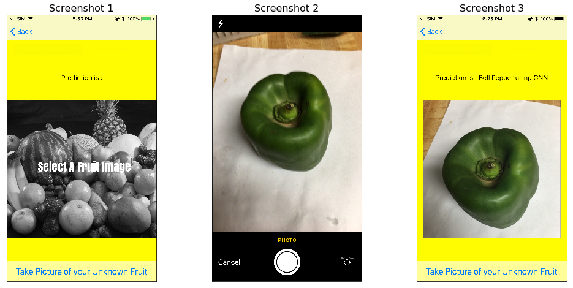

```python
dir_path = r'D:\\Downloads\\Notes\\CSE_7324_ML\\fruits-360_dataset_2018_02_08\\ios\\*'
plt.figure(figsize=(17,8))
count = 1
for image_path in glob.glob(dir_path):
    image = cv2.imread(image_path,cv2.IMREAD_COLOR)
    image = cv2.cvtColor(image, cv2.COLOR_RGB2BGR)
    plt.subplot(1,3,count)
    plt.imshow(image)
    remove_axis_visibility(plt)
    plt.title("Screenshot {}".format(count),fontsize=16)
    count +=1
```

**Screenshot 1**  
Prompts the user to take the picture of an unknown fruit

**Screenshot 2**  
user calling the default camera app, taking the picture & uploading it on the tornado server to get the predicted label

**Screenshot 3**  
Get the predicted result from the CNN model on the server & is displayed to the user

## Prediction outcomes

==== Easy Cases ====

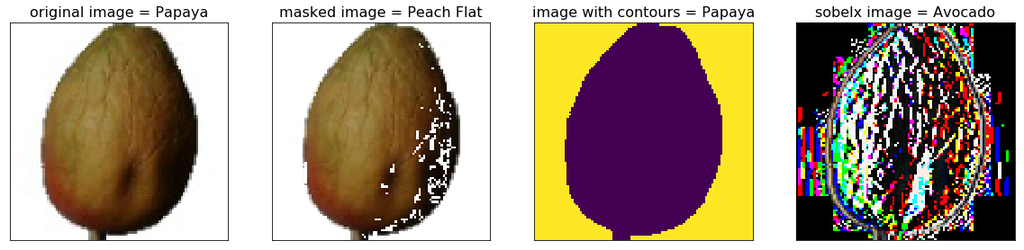

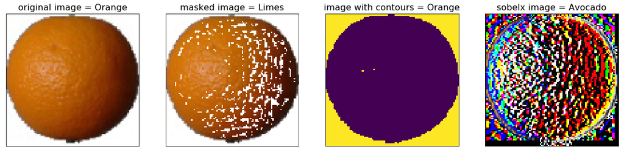

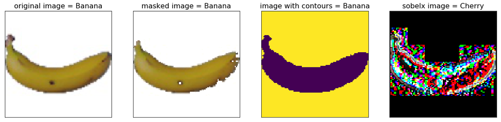

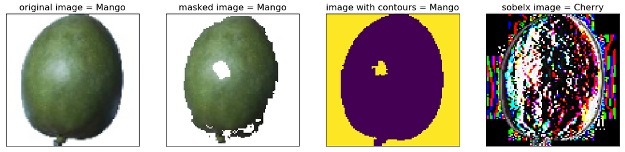

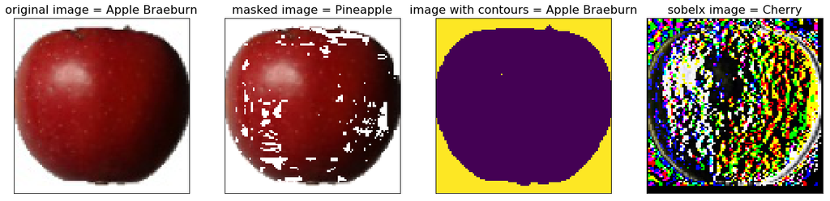

==== Medium Cases ====

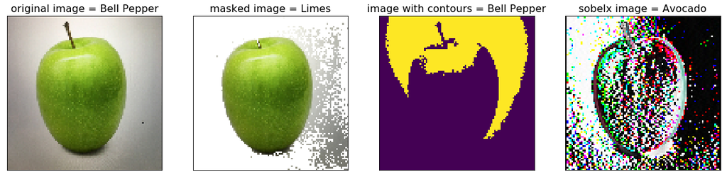

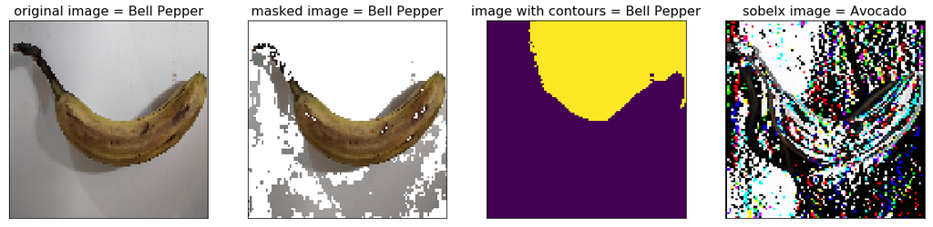

==== Hard Cases ====

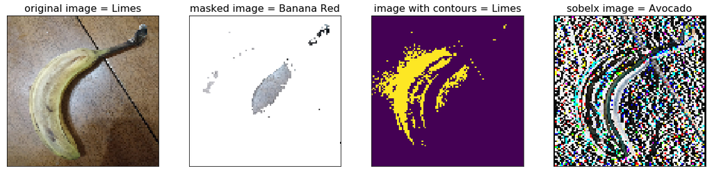

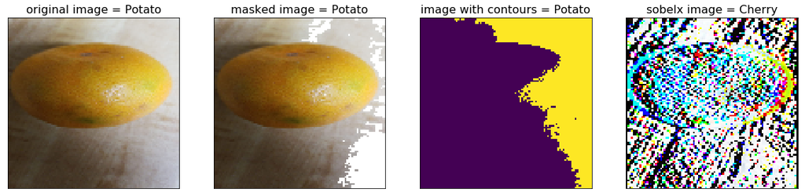

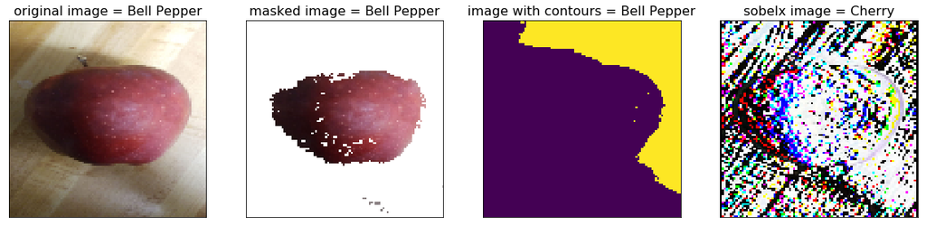

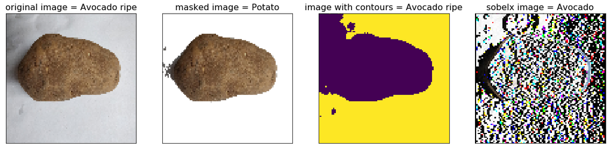

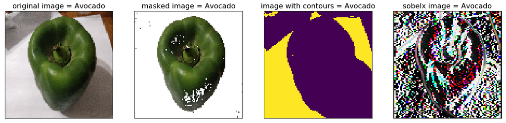

```python
dir_path = r'D:\\Downloads\\Notes\\CSE_7324_ML\\fruits-360_dataset_2018_02_08\\predict\\*'
display(HTML('<br><br><h1>==== Easy Cases ====</h1><br><br>'))
for image_path in glob.glob(dir_path):
    image = cv2.imread(image_path,cv2.IMREAD_COLOR)
    image = cv2.resize(image, (100, 100))
    sobelx = cv2.Sobel(image,cv2.CV_64F,1,0,ksize=1)
    im2 = image_with_contours(image)
    res = mask_image(image)
    image = cv2.cvtColor(image, cv2.COLOR_RGB2BGR)
    if int(image_path.split("\\")[-1].split('.')[0]) == 20:
        display(HTML('<br><br><h1>==== Medium Cases ====</h1><br><br>'))
    if int(image_path.split("\\")[-1].split('.')[0]) == 30:
        display(HTML('<br><br><h1>==== Hard Cases ====</h1><br><br>'))
    plt.figure(figsize=(20,8))
    plt.subplot(1,4,1)
    plt.imshow(image)
    plt.title("original image = %s" % predict(image),fontsize=16)
    remove_axis_visibility(plt)
    plt.subplot(1,4,2)
    plt.imshow(res)
    plt.title("masked image = %s" % predict(res),fontsize=16)
    remove_axis_visibility(plt)
    plt.subplot(1,4,4)
    plt.imshow(sobelx)
    plt.title('sobelx image = %s'%predict(sobelx),fontsize=16)
    remove_axis_visibility(plt)
    plt.subplot(1,4,3)
    plt.imshow(im2)
    plt.title('image with contours = %s'%predict(image),fontsize=16)
    remove_axis_visibility(plt)
    plt.show()
```

## Video Demo

This video demostrates the working model of our final software.

[video not shown]

Link : **https://www.youtube.com/watch?v=0eGLE8gpv4Q**

## Conclusion

Easy Cases

> 1. After regressive testing, we get an accuracy of over 97%
> 2. this was the validation set provided along with the dataset in kaggle.

Medium Cases

Hard Cases

> 1. We clicked real images of fruit with complicated background.
> 2. The results here were very poor, we were getting around 15-20% accuracy from our testing.
> 3. The model is not trained to handle real image data since there are no such sample in the dataset

## Solution for better accuracy

In order to increase accuracy in the Medium & hard cases, we need more sample data of those types, meaning the bakground should be complex. If we get images of the same sample fruits in different backgrounds in sufficient number. We would see an increase in the accuracy for medium and hard cases.